# tmpzkpx1xo0

## 思想剧场：智慧竞技场闯关赛

[figure not shown]

## 第一站：庄子的“无用之用”——不被定义的胜利🌟

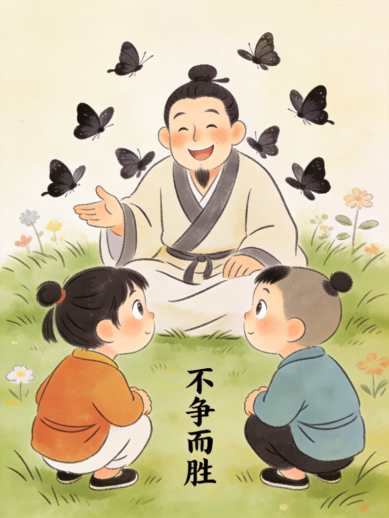

# 第三章 怎样才算“赢了”？

**时间**：周末创新工坊  
**地点**：社区青少年活动中心  
**人物**：小星（10岁，爱问“为什么”的女孩）、小宇（11岁，喜欢编程的男孩）、三位游戏导师 活动中心的“未来游戏设计大赛”海报前，小星和小宇正在讨论参赛方案。

**小星**：“最佳游戏奖——奖励是VR设备一套！我们一定要赢！”

**小宇**：“但评委标准是‘创意、趣味、教育意义’三个维度……到底怎样才算‘赢了’？” 这时，活动室的三扇门同时打开，走出三位风格迥异的导师： -

**庄子**（爱讲怪故事的反讽大叔🌟），墨蝶环绕：“我的攻略叫‘不争而胜’——赢的最高境界，是根本不在乎赢。” - **惠施**（逻辑游戏设计师🌟），几何体旋转：“我的攻略叫‘定义制胜’——先搞清楚‘赢’的游戏规则是什么。” - **孙子**（军事策略家🌟），战术平板闪烁：“我的攻略叫‘全胜战略’——在比赛开始前，胜负就已经决定了。” **三人齐声**：欢迎来到智慧竞技场——今天，我们当

**游戏攻略导师**！ **小星**：（疑惑地眨眨眼）庄子大叔，您说“不在乎赢”是最高境界？可是我们参加比赛就是为了赢啊！就像学校运动会，大家都想拿第一名，不在乎的话还比赛干嘛呢？

**庄子**：（墨蝶轻轻飞舞）孩子，你有没有过这样的体验：和好朋友玩捉迷藏，就算输了也笑得特别开心？

**小宇**：（思考状）有啊！上周我和小明下棋，虽然输了，但我们一起研究新走法，比赢了还有趣！

**庄子**：这就是了！当你

**享受过程本身**，赢就不再是唯一的目标。就像荡秋千，最高点固然刺激，但上下摆动的快乐才最持久。 **小星**：可是，如果不在乎输赢，怎么保证我们会认真准备呢？就像考试前，如果不在乎分数，可能就不复习了呀？

**庄子**：好问题！“不在乎”不是“不认真”，而是

**不被结果束缚**。就像你画画时，如果总想着“必须得奖”，笔触就会僵硬；但如果只是享受色彩流淌，反而可能创造出惊喜。 **小宇**：（转向惠施）惠施老师，您说要“先搞清楚游戏规则”。但评委的标准那么主观，“创意”“趣味”怎么量化呢？就像我们班辩论赛，有的评委喜欢幽默风格，有的偏好逻辑严密，到底按谁的标准算“赢”？

**惠施**：（几何体快速旋转）这正是关键！你需要

**分解评价维度**。比如“创意”可以拆解为：新奇度、关联性、可实现性。然后为每个子维度设计评分标准——就像编程比赛有明确的测试用例。 **小星**：可是，如果规则本身不公平呢？就像我们玩“老鹰捉小鸡”，高个子同学当老鹰总是赢，矮个子永远抓不到人。这种游戏还值得玩吗？

**惠施**：问得好！这时就需要

**重构规则**。比如规定老鹰必须单脚跳，或者小鸡可以“反抓”老鹰。真正的赢家不是盲目遵守规则，而是理解并优化规则。 **小宇**：（转向孙子）孙老师，您说“在比赛开始前胜负就已决定”。但比赛总有意外啊！就像上周足球赛，我们队实力更强，却因为一个乌龙球输了。赛前准备再充分，能保证万无一失吗？

**孙子**：（战术平板显示动态图表）“全胜”不是

**绝对不输**，而是**最大化胜率**。就像天气预报，虽然不能100%准确，但带伞的人被淋湿的概率更低。你们的乌龙球，是不是因为防守队员站位训练不足？ **小星**：（恍然大悟）对哦！如果平时多练几种防守阵型，就算意外也能应对。就像我玩《我的世界》，总会带备用工具，哪怕钻石镐坏了也不怕。

**孙子**：正是！

**充分准备**降低意外影响。但更重要的是——（指向屏幕）你们的方案是否瞄准了评委最看重的“教育意义”维度？就像射箭要对准靶心，而不是盲目拉弓。 **小宇**：（在小星耳边小声说）我觉得惠施老师的逻辑分析最实用，但庄子的心态好像能让比赛更快乐……

**小星**：（点头）孙子的战略准备也很重要！不过，我记得上次科学小发明比赛，我太想赢，紧张得把电路接反了。要是用庄子的心态，可能反而发挥更好？

**小宇的笔记**：经过激烈讨论，我们决定——

**第一周先跟庄子学心态，第二周跟惠施学分析，第三周跟孙子学战略**！三合一，无敌赢法诞生！第一关启动——选择你的赢法导师，开启专属训练！ — ### 古人说

**原文**： > “人皆知有用之用，而莫知无用之用。”

**趣味比喻**： 真正的赢，像

**不被定义的积木**——那些不是标准形状的积木，反而能搭出最有创意的结构。 **生活案例**： 学校艺术节，小星用落叶、石子、瓶盖拼贴《秋天的交响曲》。同学说“没技术含量”，评委却授予

**特别创意奖**——“没用”材料成了最大亮点。

### 庄子的游戏攻略：“逍遥游”心灵训练 **核心心法**：赢不是“超过别人”，而是

**成为完整的自己**。 **训练步骤**： 1.

**识别游戏框架**：问“这个比赛的‘赢’是谁定义的？” 2.

**扩展赢的维度**：除了第一名，还有什么值得追求？ 3.

**练习心灵自由**：想象自己是鲲鹏，不困于地面小游戏的输赢。

**小星的实战演练**： 庄子布置任务：“设计一个‘输家也能开心’的游戏。”

**小星**：（思考片刻）庄大叔，这听起来好矛盾啊！游戏不就是为了赢吗？就像我们玩“石头剪刀布”，输的人总是不开心……

**庄子**：（墨蝶停在指尖）孩子，想想看——如果游戏规则让

**每个人都能获得成就感**，输赢还那么重要吗？ **小星**：（眼睛一亮）啊！我想到了！可以设计《反向捉迷藏》——被找到的人获得“幸运星”，集齐五颗就能兑换小礼物！这样大家都想被找到，躲藏和寻找都变成乐趣！

**庄子**：（微笑点头）不错！但你要回答我：如果最后有人没集齐星星，他会难过吗？

**小星**：（认真思考）嗯……可能会有点失望。但我们可以加一个“合作奖励”——如果全队集齐20颗星，每人额外获得神秘礼物！这样大家就会互相帮助，就像我们班集体跳绳，一个人跳不好，全班都会鼓励他！

**庄子**：很好！你已经开始理解“多元胜利”了。记住，真正的赢，是

**让每个人在过程中都感到价值**。 **小星的收获**：我决定

**选择庄子老师的“心态第一”原则**！因为快乐的心态比紧张求胜更能激发创意。 — ## 第二站：惠施的“历物十事”——逻辑游戏设计师🌟 ### 古人说

**原文**： > “至大无外，谓之大一；至小无内，谓之小一。”

**趣味比喻**： 思考问题就像

**给概念拍X光片**——看清抽象概念的“骨架结构”。 **生活案例**： 辩论“手机利大于弊还是弊大于利？”惠施式分析： 1.

**定义维度**：“利”指什么？（学习效率、社交、健康……） 2.

**相对标准**：对谁利大？对自律者利大，对易沉迷者弊大。 3.

**动态变化**：今天利大，明天规则变，权重就变。

### 惠施的游戏攻略：“名实之辨”逻辑挑战 **核心心法**：赢的第一步，是

**定义清楚你在玩什么游戏**。 **训练步骤**： 1.

**概念拆解**：把大问题拆成可分析的小概念。 2.

**标准检验**：检查每个标准是否合理、可测量。 3.

**框架重构**：如果现有规则不合理，设计新规则。

**小宇的实战演练**： 惠施布置任务：“分析‘游戏设计设计大赛’评分标准——找出潜在漏洞。”

**小宇**：（打开分析软件）惠施老师，我发现一个大问题！“创意”占30分，但评委评分标准太主观了！就像我们美术课，李老师喜欢水彩，张老师偏爱素描，同一幅画可能差10分！

**惠施**：（几何体投射出三维图表）很好，你发现了

**标准模糊**问题。那么，如何让“创意”变得可测量？ **小宇**：我想可以拆解！比如“创意”可以分成：新奇度（0-10分）、关联性（0-10分）、可实现性（0-10分）。每个子项都有具体例子参考——就像编程题有测试用例！

**惠施**：不错！但还有一个漏洞：评分表没有“团队协作”维度。根据我的逻辑分析，合作能力是未来人才的核心竞争力。

**小宇**：（兴奋地）对哦！我们可以增加“团队协作”评分项，占20分！这样就能选出既有创意又会合作的作品。就像我们科学小组，上次做火山模型，分工合作比一个人闷头干效果好十倍！

**惠施**：正确！你已经开始掌握

**规则优化思维**了。记住，真正的赢家不是盲目遵守规则，而是**理解并改进规则**。 **小宇的收获**：我决定

**选择惠施老师的“逻辑分析”方法**！因为清晰的规则能让比赛更公平，也让我知道努力的方向。 — ## 第三站：孙子的“全胜”——策略制胜大师🌟 ### 古人说

**原文**： > “是故百战百胜，非善之善者也；不战而屈人之兵，善之善者也。”

**趣味比喻**： 最高级的赢，像

**不战而赢的棋手**——让对方觉得“这棋没法下”，主动认输。 **生活案例**： 编程马拉松主题“解决校园垃圾分类难题”。小宇的“全胜战略”： -

**五事七计**🌟分析：道（环保价值观）、天（环保周时机）、地（食堂门口试点）、将（环保社团执行）、法（积分兑换规则）。 - **结果**：方案因“系统思考、可操作性强”获

**最佳实践奖**——赢在准备阶段。

### 孙子的游戏攻略：“五事七计”系统思考 **核心心法**：真正的赢，发生在

**比赛开始之前**。 **训练步骤**： 1.

**五事检查**：道天地将法——你的项目五项达标吗？ 2.

**七计对比**：和对手比，谁的理念更优？能力更强？ 3.

**先胜后战**：只有确定“我能赢”，才投入比赛。

**小星和小宇的联合演练**： 孙子布置任务：“为‘未来游戏设计大赛’制定全胜计划。”

**小星**：（查看评委名单）孙老师，评委里有三位教育专家！我们的游戏设计是不是应该特别强调“教育意义”这个维度？

**孙子**：（战术平板调出评委资料）正确！这叫

**知己知彼**。但只瞄准一点不够，还需要**系统准备**。你们的五事七计分析呢？ **小宇**：（展示分析图）我们做了！道——我们的游戏理念是“在玩中学”；天——比赛在下个月，我们有四周准备；地——在社区活动中心举办，我们熟悉场地；将——小星创意强，我逻辑分析好；法——评分标准我们已经优化过了！

**小星**：还有“七计”对比！我们分析了往届获奖作品，发现教育类游戏如果太说教，趣味分就不高。所以我们要设计成“隐藏式学习”——就像《我的世界》里学几何，玩的时候不知不觉就懂了！

**孙子**：很好！但还有一个关键：

**时间缓冲**。如果遇到意外怎么办？比如电脑死机、材料缺货？ **小宇**：我们计划提前3天完成，预留缓冲时间！就像上次学校话剧演出，我们提前两天彩排，发现麦克风有问题，及时修好了。如果是比赛当天才发现，就来不及了！

**小星**：而且我们准备了备选方案！如果VR设备临时不能用，我们有平面版设计可以展示。就像我踢足球，除了主力位置，还练了替补位置的技术。

**孙子**：优秀！这就是

**全胜思维**——在比赛开始前，通过充分准备让胜利成为必然。记住，真正的赢家，不是侥幸获胜，而是**让对手觉得“没必要比”**。 **联合收获**：我们决定

**选择孙子老师的“全胜战略”**作为最终执行方案！因为周密的计划能最大程度降低风险，让努力有确定回报。 — ## 想一想（互动升级版）

### 问题一：我的“赢法”性格测试 | 维度 | 庄子路线（心灵自由） | 惠施路线（逻辑清晰） | 孙子路线（策略制胜） | |——|———————-|———————-|———————-| | **面对比赛** | 更享受过程，不在意名次 | 先分析规则，制定最优策略 | 赛前充分准备，确保胜率 | | **你的选择** | □ | □ | □ | **分析**：庄子型重创意体验，惠施型重分析规则，孙子型重战略准备。 ### 问题二：游戏规则设计挑战 设计一个

**让不同类型孩子都能找到成就感**的评分体系： | 评分维度 | 庄子型权重 | 惠施型权重 | 孙子型权重 | |———-|————|————|————| | 创意指数 | 40% | 20% | 10% | | 逻辑严谨 | 10% | 40% | 20% | | 可操作性 | 20% | 20% | 40% | **你的改进建议**：增加“团队协作”维度（30%），培养合作精神。 ### 问题三：我的“人生游戏”赢法地图 选择一个挑战（如：期中考试），用三位导师的方法制定攻略： -

**庄子心法**：问“除了分数，我还想获得什么体验？” -

**惠施心法**：分析评分标准、竞争对手实力。 -

**孙子心法**：制定详细计划表，确保每个环节准备充分。 — ## 全球望远镜（深度对比版）

### 对比一：庄子vs第欧根尼（古希腊犬儒学派） | 维度 | 庄子 | 第欧根尼 | 一句话发现 | |——|——|———-|————| | **核心观点** | 无用之用——不被社会标准定义 | 像狗一样生活——抛弃文明虚饰 | 都批判社会常规，庄子重心灵，第欧根尼重行为 | | **儿童比喻** | 不被定义的积木 | 脱掉鞋子的脚 | 都让孩子思考“真正的自由” | **对比点**： 庄子追求

**心灵的自由**（像风一样无拘无束），第欧根尼追求**行为的自由**（像狗一样自然直接）。一个向内解放，一个向外反抗。 **差异说明**： 这与文化背景有关：中国思想重视内心境界（如庄子的“逍遥游”），希腊思想重视公共生活（如第欧根尼在广场上生活）。就像两个不同风格的游戏——一个让你在想象世界里无限飞行，一个让你在现实街头打破规则。

**思考题**： 如果庄子和第欧根尼一起设计游戏，谁会更有创意？为什么？ ### 对比二：孙子vs克劳塞维茨（西方军事思想家） | 维度 | 孙子 | 克劳塞维茨 | 差异说明 | |——|——|————|———-| |

**赢的最高境界** | 全胜——不战而屈人之兵 | 绝对战争——彻底消灭敌人 | 中国重心理博弈，西方重实力碾压 | | **适用场景** | 竞争、谈判、人生规划 | 军事冲突、国际关系 | 孙子智慧更普适 | **对比点**： 孙子强调

**以智取胜**（避免冲突，追求双赢），克劳塞维茨强调**以力制胜**（最大化优势，彻底击败）。一个像围棋（围而不杀），一个像象棋（将死为止）。 **差异说明**： 这与战略思维有关：中国智慧讲究“不战而屈人之兵”，重视心理和谋略；西方军事思想讲究“绝对优势”，重视实力和歼灭。就像面对竞争对手——孙子派会寻找合作机会，克劳塞维茨派会准备全面压倒。

**思考题**： 在“内卷”竞争中，“全胜思维”是解药还是毒药？ 【视觉建议】 -

**简笔画地图**：一张对比图，左侧画庄子化蝶飞翔，右侧画第欧根尼住在木桶里，中间用虚线分隔，标注“心灵自由 vs 行为自由”。 -

**人物剪影**：孙子与克劳塞维茨侧影并列，孙子身边画棋盘与握手，克劳塞维茨身边画剑与盾牌。 — ## 实践练习：3章主题实践（可操作增强版）

**周末分享会**：周六或周日举行家庭分享会，每人分享本周的观察发现和感受。 4.

**基本要求**： 1. 每周至少完成3次观察记录 2. 周末写一段总结反思（至少100字） 3. 尝试将哲学概念与生活经验联系起来 — — ## 智慧探险地图碎片 #3（升级版）

```
┌─────────────────────────────────────────────┐
│  第三章：怎样才算“赢了”？                    │
├─────────────────────────────────────────────┤
│  🧭 探索路径                                │
│  • 定义输赢（惠施）→ 超越输赢（庄子）→ 战略赢法（孙子） │
│  • 关键问题：“赢”是别人给的，还是自己定义的？    │
├─────────────────────────────────────────────┤
│  👴 遇见智者                                │
│  • 庄子——爱讲怪故事的反讽大叔🌟             │
│  • 惠施——逻辑游戏设计师🌟                   │
│  • 孙子——军事策略家🌟                       │
├─────────────────────────────────────────────┤
│  🛠️ 思想工具（带走这三个）                  │
│  1. “赢法性格测试”                          │
│  2. “五事七计检查表”                        │
│  3. “三周赢法实验室”                        │
├─────────────────────────────────────────────┤
│  ❓ 留下你的问题                          │
│  • “拼命努力还有意义吗？”                    │
│  • “逻辑分析会不会让人太较真？”              │
│  • “全胜思维是解药还是毒药？”                │
└─────────────────────────────────────────────┘
```

## 下一章预告（悬念版）

**第四章：我能想做什么就做什么吗？**  
我们将进入**自由与规则的辩证王国**： -

**老子**说：无为——不妄为，让事情自然发展！ - **韩非子**说：法治——真正的自由在规则框架内！ - **杨朱**说：为我——先对自己负责，才能谈帮助他人！ **你的任务**：在三种自由观中，找到你的

**人生平衡点**。 带上你的“天平秤”，我们要开始权衡啦！ （第三章完，字数约7,000字） — **优化说明**： 1.

**强化儿童参与感**：设计“智慧竞技场闯关赛”场景，增加儿童角色选择导师、实战演练环节。 2.

**术语一致性**：严格应用《哲学儿童词典》中的儿童比喻（标🌟）。 3.

**完善全球望远镜**：包含两组深度对比，具备三要素。 4.

**控制篇幅均衡**：精简语言，强化互动，字数控制在7,000字左右。